# BGA Genomic Annotations Lab

Chad Shaw Laboratory

4/6/2017

This document was created at Tue Apr 25 13:25:28 2017. If any changes have been introduced lately they can be found [here](http://htmlpreview.github.io/?https://github.com/andrewGhazi/genomicAnnotationsLab/blob/master/bgaGenomicAnnotationsLab.html).

## Pre-Lab

The lab can be run from Sphere, but it will be easier to complete if you use RStudio.

- Install R: https://cran.r-project.org/
- Install RStudio: https://www.rstudio.com/products/rstudio/download/
- Install packages needed for this lab (in R): `install.packages(pkgs = c('corpcor', 'magrittr', 'stringr', 'readr', 'devtools', 'tidyverse'))` or
  - Don’t do this if you’re running the lab from an R console on Sphere. Instead type `declare -x R_LIBS_USER="/home/student20/R/x86_64-redhat-linux-gnu-library/3.2"` in bash before starting R.
- Install the lab package: `devtools::install_github('andrewGhazi/genomicAnnotationsLab')`

Test that you’ve got the package installed correctly by loading the package with `library(genomicAnnotationsLab)` and running `?makeScore` to look at the help documentation for a function we will be using.

There’s nothing to turn in for the pre-lab.

## Note on R coding style

This lab is designed to adhere to tidy principles where possible. This means keeping data in data_frames with rows representing observations and columns as variables.

It also makes use of pipes `%>%` which take their left hand side and pipe it into the right-hand side as the first argument. Pipes are THE BEST, so make sure to internalize the keyboard shortcut to insert them: `ctrl + shift + M` (`⌘ + shift + M` on Mac).

## Setup

### Libraries, scripts

Before getting started, let’s load some useful packages software packages:

```r
library(tidyverse) # for data tidying, manipulating, and visualizing. Includes dplyr and ggplot2 among others
# library(dplyr); library(tidyr); library(ggplot2) # if the full tidyverse isn't installed
library(genomicAnnotationsLab) # Loads in the scoring functions and data
library(stringr) # tidy manipulation of strings
```

Again, if you’re running R on Sphere, you will need to enter `declare -x R_LIBS_USER="/home/student20/R/x86_64-redhat-linux-gnu-library/3.2"` into the terminal before starting R.

### Data

We’ll be using 3 objects that are loaded in with the genomic annotations package:

- eGenes - a character vector containing genes that contain eQTLs that effect their expression in platelets.
- humanGO - a sparse matrix describing which genes (rows) are annotated under which Gene Ontology (GO) terms
- goterms - a data frame containing a mapping between GO IDs (e.g. GO:0000011) and (e.g. vacuole inheritance).

```r
eGenes %>% head #head shows the first 6 elements of a vector
```

```
## [1] "SMAD5"  "TMEM56" "FHL3"   "MFN2"   "AKAP9"  "DHRS7"
```

Let’s also inspect the matrix `humanGO` which describes which genes are annotated under which GO terms.

```r
dim(humanGO)
```

```
## [1] 18895 16008
```

```r
humanGO[1:5,1:5] #Print the first five rows of the first five columns as a small sample
```

```
## 5 x 5 sparse Matrix of class "dgCMatrix"
##        GO:0048308 GO:0048311 GO:0007005 GO:0000002 GO:0008150
## 44M2.3          .          .          .          .          .
## A1BG            .          .          .          .          1
## A1CF            .          .          .          .          1
## A2LD1           .          .          .          .          1
## A2M             .          .          .          .          1
```

```r
goterms
```

```
## # A tibble: 36,517 × 3
##            ID                                                         term
##         <chr>                                                       <fctr>
## 1  GO:0000001                                    mitochondrion inheritance
## 2  GO:0000002                             mitochondrial genome maintenance
## 3  GO:0000003                                                 reproduction
## 4  GO:0000005                                 ribosomal chaperone activity
## 5  GO:0000006 high affinity zinc uptake transmembrane transporter activity
## 6  GO:0000007     low-affinity zinc ion transmembrane transporter activity
## 7  GO:0000008                                                  thioredoxin
## 8  GO:0000009                       alpha-1,6-mannosyltransferase activity
## 9  GO:0000010                    trans-hexaprenyltranstransferase activity
## 10 GO:0000011                                          vacuole inheritance
## # ... with 36,507 more rows, and 1 more variables: Domain <fctr>
```

So for instance we see that 4 genes are annotated under GO:0008150. We can use filter on the term mapping data_frame `goterms` to see what this term is:

```r
goterms %>%
  filter(ID == 'GO:0008150')
```

```
## # A tibble: 1 × 3
##           ID               term Domain
##        <chr>             <fctr> <fctr>
## 1 GO:0008150 biological_process      P
```

So these genes are annotated under `biological_process`.

## Annotation Scoring

The scoring software takes a set of annotations and a set of genes. It then uses the covariance of annotations in a given gene set’s annotations to find which terms are enriched.

In this code block, we first run the scoring software. This can take a minute or two depending on the size of the annotation source.

```r
annoOutput = makeScore(humanGO, eGenes)
```

```
## [1] "Done selecting Annotations: 186"
## [1] "Done computing BG scores."
## [1] "Done computing background quadratic form."
## [1] "Done computing training set quadratic form."
```

Let’s inspect the structure of the output:

```r
annoOutput %>% class() #use class() to see the type of an object
```

```
## [1] "list"
```

```r
annoOutput %>% length() #use length to find the length of vectors or lists
```

```
## [1] 2
```

```r
annoOutput %>% names() #This list is named, so we can use names to see the names of the two elements
```

```
## [1] "Scores"               "Enriched.Annotations"
```

```r
annoOutput$Scores %>% head # Use `$` to access the elements of a named list. Scores is a named vector of gene scores.
```

```
##      44M2.3        A1BG        A1CF       A2LD1         A2M       A2ML1
## -0.06478775 -0.78086699 -0.13295101  0.33343100  1.63888871  1.26577846
```

```r
annoOutput$Enriched.Annotations %>% class # enrichedAnnotations is a matrix describing which annotations are enriched among our training genes.
```

```
## [1] "matrix"
```

```r
annoOutput$Enriched.Annotations[1:2,] #This matrix does not print nicely
```

```
##            TermID       Count Total  OddsRatio
## GO:0005515 "GO:0005515" "265" "6901" "1.56736635084377"
## GO:0016765 "GO:0016765" "6"   "53"   "4.19012743638328"
##            Pvalue
## GO:0005515 "2.29370389512083e-07"
## GO:0016765 "0.0047710418821896"
##            Genes
## GO:0005515 "SMAD5,FHL3,MFN2,AKAP9,SERPING1,ANXA5,KLHL5,NAPG,PXK,HTATIP2,RUFY1,CD164,GRB14,COPS4,SERPINE2,NAP1L4,NCOA3,FHL2,YWHAB,CBR4,NDFIP1,AGFG1,VAMP8,PDK1,CLIP1,ACR,ITGA2,PF4V1,PROK2,VPS26A,EFTUD2,FOXJ2,ITGB3BP,REEP1,APH1B,CAP1,DNM1L,SPTBN1,BTBD2,ATP11B,GTF2A2,RCOR3,ADI1,FUT8,TGFB2,GRK5,ATF6,C…
## GO:0016765 "GSTM1,GSTA1,GSTM4,GSTM5,MGST3,PDSS1"
```

Given that this output is sort of messy, let’s tidy it up a bit by putting them into two data frames, `geneScores` and `enrichedAnnotations`.

```r
#create a data_frame with the symbols, scores, and a logical indicating whether or not it belonged to the training set
geneScores = data_frame(gene_symbol = names(annoOutput$Scores),
                        score = annoOutput$Scores,
                        inTrainSet = gene_symbol %in% eGenes) %>%
  arrange(desc(score)) %>% #order it by descending score
  mutate(gene_symbol = factor(gene_symbol, levels = gene_symbol)) %>% # mutate to overwrite an existing variable
  filter(!is.na(score)) #remove the one gene that wasn't in the annotation source

#create a data_frame from the enriched annotation information
enrichedAnnotations = annoOutput$Enriched.Annotations %>%
  as.data.frame(stringsAsFactors = FALSE) %>%
  as.tbl %>%
  mutate(Count = as.integer(Count), # convert them to the appropriate types
         Total = as.integer(Total),
         OddsRatio = as.numeric(OddsRatio),
         Pvalue = as.numeric(Pvalue),
         Genes = str_split(Genes, ',')) %>% # List column!
  arrange(Pvalue) %>% # sort rows p value
  rename(ID = TermID) %>% #rename for the join
  left_join(goterms, by = 'ID') #join to the term description matrix from before
```

### Inspect enriched annotations

Let’s look at what terms characterize our platelet eGenes. The software defaults to a Pvalue < .01 cutoff, but since we’re selecting from thousands of GO terms let’s impose an $\alpha$ = .05 Bonferroni-adjusted cutoff.

```r
enrichedAnnotations %>%
  filter(Pvalue < .05 / ncol(humanGO))
```

```
## # A tibble: 20 × 8
##            ID Count Total OddsRatio       Pvalue       Genes
##         <chr> <int> <int>     <dbl>        <dbl>      <list>
## 1  GO:0005737   383  9064  2.365438 2.463443e-22 <chr [383]>
## 2  GO:0044444   295  6623  2.088034 1.560809e-17 <chr [295]>
## 3  GO:0044424   452 12270  2.244411 7.696593e-16 <chr [452]>
## 4  GO:0005622   462 12686  2.285545 1.204868e-15 <chr [462]>
## 5  GO:0043229   400 10591  1.960254 1.536582e-13 <chr [400]>
## 6  GO:0043226   400 10607  1.953336 2.111999e-13 <chr [400]>
## 7  GO:0044422   277  6642  1.820973 5.019360e-12 <chr [277]>
## 8  GO:0044446   274  6565  1.814677 6.137303e-12 <chr [274]>
## 9  GO:0043231   361  9514  1.792138 2.587957e-11 <chr [361]>
## 10 GO:0043227   361  9525  1.787843 3.405915e-11 <chr [361]>
## 11 GO:0005829   118  2280  1.983197 1.484080e-09 <chr [118]>
## 12 GO:0031090   116  2280  1.938857 5.213823e-09 <chr [116]>
## 13 GO:0016192    54   833  2.390341 9.295411e-08  <chr [54]>
## 14 GO:0015629    31   361  3.178388 1.427873e-07  <chr [31]>
## 15 GO:0005515   265  6901  1.567366 2.293704e-07 <chr [265]>
## 16 GO:0012505    85  1694  1.848043 1.907344e-06  <chr [85]>
## 17 GO:0031982    54   917  2.147371 1.941905e-06  <chr [54]>
## 18 GO:0044464   491 15046  1.769546 2.104226e-06 <chr [491]>
## 19 GO:0031410    52   877  2.159290 2.150905e-06  <chr [52]>
## 20 GO:0005623   491 15047  1.768956 2.650293e-06 <chr [491]>
## # ... with 2 more variables: term <fctr>, Domain <fctr>
```

The top enriched term is ‘cytoplasm’. Given that platelets don’t have nuclei and thus any proteins they use must be localized to the cytoplasm or other organelles, this makes sense!

### Inspect Scoring Results

`geneScores` is a data_frame containing the similarity scores of each gene to the training set, as well as an indicator variable stating whether or not it was in the training set.

```r
geneScores
```

```
## # A tibble: 18,894 × 3
##    gene_symbol    score inTrainSet
##         <fctr>    <dbl>      <lgl>
## 1      HSBP1L1 3.330032      FALSE
## 2         DPP4 3.253372      FALSE
## 3       AVPR1A 3.251516       TRUE
## 4        DHRS4 3.246730      FALSE
## 5         ZER1 3.236314      FALSE
## 6       BCL11A 3.226005      FALSE
## 7        TGFB2 3.225058       TRUE
## 8       CAPZA3 3.214577      FALSE
## 9     CTNNBIP1 3.202875      FALSE
## 10        COQ5 3.200195      FALSE
## # ... with 18,884 more rows
```

Let’s try to visualize how well the scoring process worked.

We can plot each gene’s rank against its score and color according to whether or not it belonged to the training set to see how well it turned out. If you’re running from Sphere, set the output equal to a variable (for example `p = ggplot(data, aes(x,y)) + geom_point()`) then use `ggsave` to save the ggplot to a file (e.g. `ggsave(p, '/path/to/output.png')`) that you can then copy over to your computer (using `scp` or something).

We can create plots with `ggplot()`. This function takes a data_frame and an aesthetic mapping of variables created with `aes()`. With that you layer on additional geometric objects and other plot parameters by iteratively adding them on with `+`.

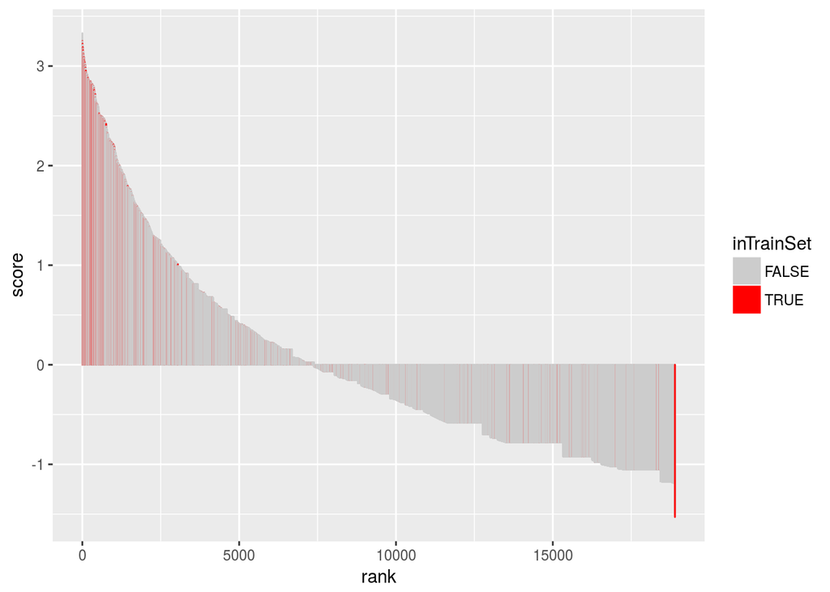

```r
p = geneScores %>%
  mutate(rank = 1:nrow(geneScores)) %>% # We sorted it by score earlier, so add a ranking variable with mutate
  ggplot(aes(x = rank, y = score)) + # initialize the ggplot
  geom_col(aes(color = inTrainSet, # Add a bar for each gene
               fill = inTrainSet)) + # Use an aesthetic mapping of group membership to color
  scale_fill_manual(values = c('grey80', 'red')) + #set the colors to be used
  scale_color_manual(values = c('grey80', 'red'))
p
```

```r
#ggsave(p, 'plots/rankPlot.png')
```

Let’s try comparing the training and non-training sets directly. An old-fashioned way of doing this would be with side-by-side boxplots, however plotting the data itself as a jittered stripchart is a more informative visualization that doesn’t rely on summary statistics. Transparency helps prevent overplotting, and overlaid violin plots (red) show density estimates by group.

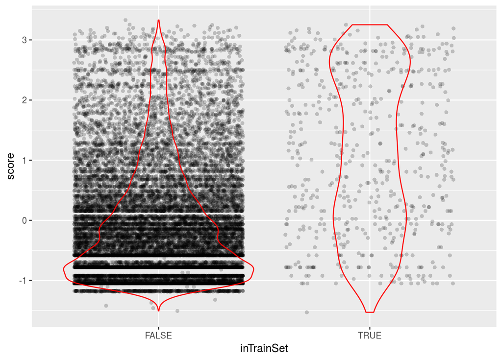

```r
p2 = geneScores %>%
  ggplot(aes(x = inTrainSet, y = score)) +
  geom_point(position = 'jitter', alpha = .2, shape = 16) + #alpha sets the transparency
  geom_violin(alpha = 0, color = 'red')
p2
```

```r
#ggsave(p2, 'plots/jitterPlot.png')
```

The training set is clearly enriched among higher scoring genes. However there are also training genes with very low scores – this implies that there’s some degree of heterogeneity among the training genes. Let’s take a look at the genes that are high scoring and NOT in the training set.

```r
geneScores %>%
  filter(!inTrainSet, score > 2.5) # You can add more conditions to filter as additional arguments
```

```
## # A tibble: 475 × 3
##    gene_symbol    score inTrainSet
##         <fctr>    <dbl>      <lgl>
## 1      HSBP1L1 3.330032      FALSE
## 2         DPP4 3.253372      FALSE
## 3        DHRS4 3.246730      FALSE
## 4         ZER1 3.236314      FALSE
## 5       BCL11A 3.226005      FALSE
## 6       CAPZA3 3.214577      FALSE
## 7     CTNNBIP1 3.202875      FALSE
## 8         COQ5 3.200195      FALSE
## 9         COQ6 3.200195      FALSE
## 10        COQ9 3.200195      FALSE
## # ... with 465 more rows
```

These can be prioritized as potential new members of the training set in followup studies.

## Lab problems

For the homework, you’ll repeat the lab with a different annotation source and gene set. Show your code and appropriate outputs in a document. If you’d like to learn how to author analysis documents (like this lab), using RMarkdown from with RStudio would be a good way to do this. Otherwse a PDF containg your code, comments, and figures will do.

1. Choose an alternate annotation source. There’s another dataset called `miRNA` included with the package that shows how >30,000 genes are annotated in miRBase. You can use this but you can earn a bonus point if you compile your own annotation matrix from a source that’s personally interesting to you :). Alternative annotation sources could come from KEGG, protein-protein interaction networks, or Mouse Genome Informatics – any source that provides genomic annotations for many genes.  
   Note that while the Gene Ontology is a binary annotation for each term (e.g. a given gene either is or is not annotated under ‘GO:000002’) this method also works for continuous annotations.
2. Reshape your input annotations into a matrix (if necessary). Use the genes as rows and the annotation variables as columns. Make sure that the matrix has the appropriately set row and column names (set with `rownames(mat) = gene_name_vector` and `colnames(mat) = annotation_variable_name_vector`). Use `Matrix::Matrix()` if the matrix is sparse and uses too much memory.
3. Select your favorite set of genes and import them into R as a character vector. Make sure there’s enough that they could conceivably show some characteristic patterns (use `length()`). Check what fraction of them are annotated in your annotation source (hint: use `%in%`).
4. Run the annotation software by calling `makeScore(AnnotationMatrix, TrainingGenes)`. This outputs a list with two elements. The first, named ‘Scores’ is a named vector giving the score for each gene. The second, ‘Enriched.Annotations’, is a matrix. If you’d like to tidy them into data_frames, lift over the code from the lab. Provide some interpretation of your results like we did in the lab:
- Use ggplot2 (or other plotting software as you prefer) to visualize where the training set falls in the score distribution.
- What are some high-scoring genes not in the training set?
- Why do you think they scored highly?
- What terms/variables are characteristic of your training set?
- Why do you think they are characteristic? This might be hard to answer with the miRNA annotation set since ‘hsa-mir-574-5p’ isn’t as obviously meaningful as ‘GO:0000005 ribosomal chaperone activity’. If you want to gain more insight into your gene set, re-run it with the GO annotation set from the lab and see what you get.

## Problem clarifications

### *Is there another list of genes to be using with the miRNA dataset?*

The idea was that for the problems you pick your own set of genes and use them with a new annotation source. So no, there’s not a different set of genes that you’re supposed to be using with the miRNA dataset. The only strict requirement for the gene set you choose is that the genes are annotated in the annotation source, though it’s preferable if you can consider them a coherent group in some way. That way you will be able to ascribe meaning to the results you get – the enriched terms will hopefully capture some of the properties that lead you to consider them a coherent group in the first place.

### *Just what are these annotation matrices?*

To clarify what `humanGO` is a bit further: it’s not derived from any particular dataset, it’s derived from the Gene Ontology itself. If you go to [the GO browser](http://amigo.geneontology.org/amigo) and look up a gene, on the gene’s page you’ll be able to click on a button labeled ‘GO class’ to see all of the terms it is annotated under. If you select that gene’s row from `humanGO`, you’ll see that these are the same columns that are equal to 1 and all the other columns are 0. (Or it should be pretty close, I think the GO has been updated since we assembled the humanGO matrix).

The GO itself is of course derived from experiments/data, but it’s collaboratively curated by a consortium of research institutions. They have more information about it on [their documentation site](http://geneontology.org/page/documentation).

So an annotation matrix just provides organized answers to questions about (hopefully all) genes in the genome. In `humanGO` the question asked by each column is: “Is this gene annotated under this term?” and the elements of the column are populated with 1 for “Yes” and 0 for “No”. So the 5th column asks “Is this gene annotated under GO:0008150 - biological process?” and the 2nd row of that column answers “Yes” for A1BG while the 8th row of that column answers “No” for A4D0T7.

Other example questions an annotation matrix column could answer: * Is this gene expressed in the GTEx Tibial Artery tissue? * What’s the average H3K27Ac Chip-Seq signal across this gene’s promoter region in the ENCODE data? * Does this gene interact with TP53 in a protein-protein interaction network?

Any sort of question for which there is quantitative genome-wide data. Append many columns like this and you have an annotation matrix.

### *How do I assemble an annotation matrix?*

You don’t have to if you don’t want to.

### *What if I want to?*

You’ll first want to define the unique annotation variables and genes that are annotated in the annotation source. Here’s a fake example:

```r
annotations = c('AN:001', 'AN:002', 'AN:003')
genes = c('TP53', 'BRCA2', 'GHZ')
```

Then create the matrix with the appropriate size and names:

```r
nAnno = length(annotations)
nGene = length(genes)
mat = matrix(ncol = nAnno, nrow = nGene)
colnames(mat) = annotations
rownames(mat) = genes
```

Then use a for loop over the annotation variables (columns) and set every gene (row) annotated under that annotation to 1 and all others to 0 (or the appropriate value if using a continuous annotation).

Depending on the data source it can get tricky dealing with annoyances like the semicolons and spaces in character vectors so it can be a bit tedious getting everything cleaned up into a matrix. Unless you’re already fairly proficient in R this might take a long time to do.

### *How do I get a new gene set?*

You could try the Google approach or the Biomart approach.

#### Google Approach

Google for ‘<some biological domain you’re interested in> dataset’. Look for databases that have readily downloadable datasets. For instance I searched for ‘oncogenes dataset’ and found this [Biostars page](https://www.biostars.org/p/15890/) which led me to [this database](http://ncg.kcl.ac.uk/). There’s a link to a list of Cancer Genes, which gave me a text file with two lists of known and putative cancer genes. This was just a quick example and I’m not sure how reputable that database is, but there are a ton of databases/resources out there. You will be able to find something that’s easy to work with if you poke around for a while.

Then read in your gene set. I recommend read_tsv from the readr package (which gets loaded in with tidyverse I believe). Access the column in the data_frame with $ then use the unique() function to remove duplicates.

So from this example I could do something like

```r
tmp = read_tsv('G:/Downloads/cancergenes_list.txt')
tmp$`518_Known_Cancer_Genes` %>% unique %>% head()

#[1] "ABI1"  "ABL1"  "ABL2"  "ACKR3" "ACSL3" "ACSL6"
```

#### Biomart Approach

I know BGA has a lecture on this but I’m not sure if you’ve had it yet. From the [Ensembl website](http://www.ensembl.org/biomart/martview/) you’d do something like:

1. Start a new biomart view
2. Select the ensembl genes database
3. Choose the Human Genes dataset
4. Click on filters, then select some phenotypes you’re interested in
5. Click on attributes then check gene name
6. Then click Results > export (unique results) to TSV > Go

It will give you a nice TSV that’s easy to read in with read_tsv. Again you’d want to make sure to filter down your genes to those that are in the annotation source.

### *What’s the point of this lab?*

The point of the lab was to expose you to R, genomic annotations, and statistical pattern scoring; there’s a lot of underlying subtlety and we don’t expect you to have mastered everything. Just show that you tried and explain what you learned in the document you turn in and it will be fine.